# Lab 3: Bayes Classifier and Boosting

## Jupyter notebooks

In this lab, you can use Jupyter https://jupyter.org/ to get a nice layout of your code and plots in one document. However, you may also use Python as usual, without Jupyter.

If you have Python and pip, you can install Jupyter with `sudo pip install jupyter`. Otherwise you can follow the instruction on http://jupyter.readthedocs.org/en/latest/install.html.

And that is everything you need! Now use a terminal to go into the folder with the provided lab files. Then run `jupyter notebook` to start a session in that folder. Click `lab3.ipynb` in the browser window that appeared to start this very notebook. You should click on the cells in order and either press `ctrl+enter` or `run cell` in the toolbar above to evaluate all the expressions.

Be sure to put `%matplotlib inline` at the top of every code cell where you call plotting functions to get the resulting plots inside the document.

## Import the libraries

In Jupyter, select the cell below and press `ctrl + enter` to import the needed libraries. Check out `labfuns.py` if you are interested in the details.

```python
import numpy as np
from scipy import misc
from imp import reload
from labfuns import *
import random

np.seterr(divide='ignore', invalid='ignore')
```

```
{'divide': 'warn', 'over': 'warn', 'under': 'ignore', 'invalid': 'warn'}
```

## Bayes classifier functions to implement

The lab descriptions state what each function should do.

```python
# NOTE: you do not need to handle the W argument for this part!
# in: labels - N vector of class labels
# out: prior - C x 1 vector of class priors
def computePrior(labels, W=None):
    Npts = labels.shape[0]
    if W is None:
        W = np.ones((Npts,1))/Npts
    else:
        assert(W.shape[0] == Npts)
    classes = np.unique(labels)
    Nclasses = np.size(classes)

    prior = np.zeros((Nclasses,1))

    # Assignment 2.1
    # Class is a reserved keyword, so how is this used on pg.4 in lab description??
    for jdx, klass in enumerate(classes):
        agg = W[np.where(labels==klass)[0],:]
        prior[jdx] = (agg.sum(axis=0))

    return prior

# NOTE: you do not need to handle the W argument for this part!
# in:      X - N x d matrix of N data points
#     labels - N vector of class labels
# out:    mu - C x d matrix of class means (mu[i] - class i mean)
#      sigma - C x d x d matrix of class covariances (sigma[i] - class i sigma)
def mlParams(X, labels, W=None):
    assert(X.shape[0]==labels.shape[0])
    Npts,Ndims = np.shape(X)
    classes = np.unique(labels)
    Nclasses = np.size(classes)

    if W is None:
        W = np.ones((Npts,1))/float(Npts)

    mu = np.zeros((Nclasses,Ndims))
    sigma = np.zeros((Nclasses,Ndims,Ndims))

    # Assignment 1
    for jdx, (klass, W_) in enumerate(zip(classes, W)):
        idx = np.where(labels==klass)[0] # Extract the indices for which y==class is true,
        xlc = X[idx,:]
        wlc = W[idx,:]
        mu[jdx] = sum([wi*xi for wi,xi in zip(wlc, xlc)])/ wlc.sum(axis=0)

        for dim_idx in range(Ndims):
            var = 0
            for class_vect, W_value in zip(xlc, wlc):
                var += (W_value*(class_vect[dim_idx] - mu[jdx][dim_idx])**2)
            var = var / wlc.sum(axis=0)
            sigma[jdx, dim_idx, dim_idx] = var

    return mu, sigma

# in:      X - N x d matrix of M data points
#      prior - C x 1 matrix of class priors
#         mu - C x d matrix of class means (mu[i] - class i mean)
#      sigma - C x d x d matrix of class covariances (sigma[i] - class i sigma)
# out:     h - N vector of class predictions for test points
def classifyBayes(X, prior, mu, sigma):

    Npts = X.shape[0]
    Nclasses,Ndims = np.shape(mu)
    logProb = np.zeros((Nclasses, Npts))


    # Assignment 2.2
    for jdx in range(Nclasses):
        diff = X - mu[jdx]
        log_sigma = - np.log(np.linalg.det(sigma[jdx])) / 2
        log_prior = np.log(prior[jdx])
        for i in range(Npts):
            logProb[jdx][i] = log_sigma - np.inner(diff[i]/np.diag(sigma[jdx]), diff[i]) / 2 + log_prior

    # one possible way of finding max a-posteriori once
    # you have computed the log posterior
    h = np.argmax(logProb,axis=0)
    return h
```

The implemented functions can now be summarized into the `BayesClassifier` class, which we will use later to test the classifier, no need to add anything else here:

```python
# NOTE: no need to touch this
class BayesClassifier(object):
    def __init__(self):
        self.trained = False

    def trainClassifier(self, X, labels, W=None):
        rtn = BayesClassifier()
        rtn.prior = computePrior(labels, W)
        rtn.mu, rtn.sigma = mlParams(X, labels, W)
        rtn.trained = True
        return rtn

    def classify(self, X):
        return classifyBayes(X, self.prior, self.mu, self.sigma)
```

## Test the Maximum Likelihood estimates

Call `genBlobs` and `plotGaussian` to verify your estimates.

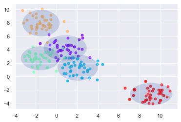

```python
%matplotlib inline

X, labels = genBlobs(centers=5)
mu, sigma = mlParams(X,labels)
plotGaussian(X,labels,mu,sigma)
```

Call the `testClassifier` and `plotBoundary` functions for this part.

```python
testClassifier(BayesClassifier(), dataset='iris', split=0.7)
```

```
Trial: 0 Accuracy 84.4
Trial: 10 Accuracy 95.6
Trial: 20 Accuracy 93.3
Trial: 30 Accuracy 86.7
Trial: 40 Accuracy 88.9
Trial: 50 Accuracy 91.1
Trial: 60 Accuracy 86.7
Trial: 70 Accuracy 91.1
Trial: 80 Accuracy 86.7
Trial: 90 Accuracy 91.1
Final mean classification accuracy  89 with standard deviation 4.16
```

```python
testClassifier(BayesClassifier(), dataset='vowel', split=0.7)
```

```
Trial: 0 Accuracy 61
Trial: 10 Accuracy 66.2
Trial: 20 Accuracy 74
Trial: 30 Accuracy 66.9
Trial: 40 Accuracy 59.7
Trial: 50 Accuracy 64.3
Trial: 60 Accuracy 66.9
Trial: 70 Accuracy 63.6
Trial: 80 Accuracy 62.3
Trial: 90 Accuracy 70.8
Final mean classification accuracy  64.7 with standard deviation 4.03
```

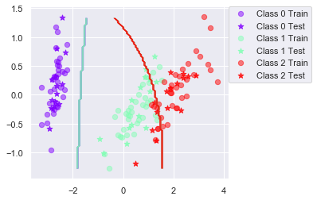

```python
%matplotlib inline
plotBoundary(BayesClassifier(), dataset='iris',split=0.7)
```

## Assignment 3

### (1) When can a feature independence assumption be reasonable and when not?

Feature independence can be reasonable where the correlation between variables is of less significance. For instance, someone's online shopping history can be used to classify them into a certain customer categories (impulse shopper, frequent buyer etc). There might be a correlation between the different purchases, but the value add might be so small that independence is a simpler way of viewing the problem and modeling it.

In contrast, for most NLP problems there will be a huge correlation between a word and the following word. If it's more of a 'classify a text as a type of factual category', word independence might work (texts about the ocean will mention the ocean, and you don't really care where it does so). But if you're trying to build an autocorrect system, not looking at the context around a word, i.e. the dependence of a word on other surrounding ones, that system is likely worse than one that takes feature dependence into consideration.

### (2) How does the decision boundary look for the Iris dataset? How could one improve the classification results for this scenario by changing classifier or, alternatively, manipulating the data?

The decision boundary looks good for the clearly separable Class 0 and Class 1, albeit it could be high variance seeing as purple looks to trend towards x = 0 the higher the y value. The Class 1 / Class 2 boundary is worse, and predicts samples from both classes incorrectly. It could be that Naive Bayes is a bit too naive for this problem, and that using a stronger classifier such as an SVM might be helpful. However, I can see how an SVM might overfit and thus introduce high variance to the problem too. Another trick could be to manipulate the data, for instance using feature scaling. It looks like multiplying the data or normalizing it might separate Class 1 and Class 2 more, while retaining the separation between Class 0 and Class 1.

## Boosting functions to implement

The lab descriptions state what each function should do.

```python
# in: base_classifier - a classifier of the type that we will boost, e.g. BayesClassifier
#                   X - N x d matrix of N data points
#              labels - N vector of class labels
#                   T - number of boosting iterations
# out:    classifiers - (maximum) length T Python list of trained classifiers
#              alphas - (maximum) length T Python list of vote weights
def trainBoost(base_classifier, X, labels, T=10):
    # these will come in handy later on
    Npts,Ndims = np.shape(X)

    classifiers = [] # append new classifiers to this list
    alphas = [] # append the vote weight of the classifiers to this list

    # The weights for the first iteration
    wCur = np.ones((Npts,1))/float(Npts)

    for i_iter in range(0, T):
        # a new classifier can be trained like this, given the current weights
        classifiers.append(base_classifier.trainClassifier(X, labels, wCur))

        # do classification for each point
        vote = classifiers[-1].classify(X)

        # Get the total number of classes to iterate over
        classes = np.unique(labels)

        epsilon = 0

        for jdx in classes:
            idx = np.where(vote == jdx)[0]
            epsilon += np.sum(np.transpose(wCur[idx]) *  (1 - (jdx == labels[idx])))

        alpha = (np.log(1 - epsilon) - np.log(epsilon)) / 2
        alphas.append(alpha)

        wOld = wCur
        # Update the weights accordingly
        for i in range(Npts):
            wCur[i] = wOld[i] * np.exp(alpha * (-1)**(vote[i]==labels[i]))
        wCur = wCur / np.sum(wCur)

    return classifiers, alphas

# in:       X - N x d matrix of N data points
# classifiers - (maximum) length T Python list of trained classifiers as above
#      alphas - (maximum) length T Python list of vote weights
#    Nclasses - the number of different classes
# out:  yPred - N vector of class predictions for test points
def classifyBoost(X, classifiers, alphas, Nclasses):
    Npts = X.shape[0]
    Ncomps = len(classifiers)

    # if we only have one classifier, we may just classify directly
    if Ncomps == 1:
        return classifiers[0].classify(X)
    else:
        votes = np.zeros((Npts,Nclasses))

        for i in range(Ncomps):
            classified = classifiers[i].classify(X)
            for j in range(Npts):
                votes[j][classified[j]] += alphas[i]

        # one way to compute yPred after accumulating the votes
        return np.argmax(votes,axis=1)
```

The implemented functions can now be summarized another classifer, the `BoostClassifier` class. This class enables boosting different types of classifiers by initializing it with the `base_classifier` argument. No need to add anything here.

```python
# NOTE: no need to touch this
class BoostClassifier(object):
    def __init__(self, base_classifier, T=10):
        self.base_classifier = base_classifier
        self.T = T
        self.trained = False

    def trainClassifier(self, X, labels):
        rtn = BoostClassifier(self.base_classifier, self.T)
        rtn.nbr_classes = np.size(np.unique(labels))
        rtn.classifiers, rtn.alphas = trainBoost(self.base_classifier, X, labels, self.T)
        rtn.trained = True
        return rtn

    def classify(self, X):
        return classifyBoost(X, self.classifiers, self.alphas, self.nbr_classes)
```

## Run some experiments

Call the `testClassifier` and `plotBoundary` functions for this part.

```python
testClassifier(BoostClassifier(BayesClassifier(), T=10), dataset='iris',split=0.7)
```

```
Trial: 0 Accuracy 95.6
Trial: 10 Accuracy 100
Trial: 20 Accuracy 93.3
Trial: 30 Accuracy 91.1
Trial: 40 Accuracy 97.8
Trial: 50 Accuracy 93.3
Trial: 60 Accuracy 93.3
Trial: 70 Accuracy 97.8
Trial: 80 Accuracy 95.6
Trial: 90 Accuracy 93.3
Final mean classification accuracy  94.1 with standard deviation 6.72
```

```python
testClassifier(BoostClassifier(BayesClassifier(), T=10), dataset='vowel',split=0.7)
```

```
Trial: 0 Accuracy 76.6
Trial: 10 Accuracy 86.4
Trial: 20 Accuracy 83.1
Trial: 30 Accuracy 80.5
Trial: 40 Accuracy 72.7
Trial: 50 Accuracy 76
Trial: 60 Accuracy 81.8
Trial: 70 Accuracy 82.5
Trial: 80 Accuracy 79.9
Trial: 90 Accuracy 83.1
Final mean classification accuracy  80.2 with standard deviation 3.52
```

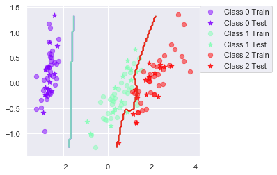

```python
%matplotlib inline
plotBoundary(BoostClassifier(BayesClassifier()), dataset='iris',split=0.7)
```

Now repeat the steps with a decision tree classifier.

```python
testClassifier(DecisionTreeClassifier(), dataset='iris', split=0.7)
```

```
Trial: 0 Accuracy 95.6
Trial: 10 Accuracy 100
Trial: 20 Accuracy 91.1
Trial: 30 Accuracy 91.1
Trial: 40 Accuracy 93.3
Trial: 50 Accuracy 91.1
Trial: 60 Accuracy 88.9
Trial: 70 Accuracy 88.9
Trial: 80 Accuracy 93.3
Trial: 90 Accuracy 88.9
Final mean classification accuracy  92.4 with standard deviation 3.71
```

```python
testClassifier(BoostClassifier(DecisionTreeClassifier(), T=10), dataset='iris',split=0.7)
```

```
Trial: 0 Accuracy 95.6
Trial: 10 Accuracy 100
Trial: 20 Accuracy 95.6
Trial: 30 Accuracy 93.3
Trial: 40 Accuracy 93.3
Trial: 50 Accuracy 95.6
Trial: 60 Accuracy 88.9
Trial: 70 Accuracy 93.3
Trial: 80 Accuracy 93.3
Trial: 90 Accuracy 93.3
Final mean classification accuracy  94.6 with standard deviation 3.65
```

```python
testClassifier(DecisionTreeClassifier(), dataset='vowel',split=0.7)
```

```
Trial: 0 Accuracy 63.6
Trial: 10 Accuracy 68.8
Trial: 20 Accuracy 63.6
Trial: 30 Accuracy 66.9
Trial: 40 Accuracy 59.7
Trial: 50 Accuracy 63
Trial: 60 Accuracy 59.7
Trial: 70 Accuracy 68.8
Trial: 80 Accuracy 59.7
Trial: 90 Accuracy 68.2
Final mean classification accuracy  64.1 with standard deviation 4
```

```python
testClassifier(BoostClassifier(DecisionTreeClassifier(), T=10), dataset='vowel',split=0.7)
```

```
Trial: 0 Accuracy 84.4
Trial: 10 Accuracy 85.7
Trial: 20 Accuracy 87.7
Trial: 30 Accuracy 90.9
Trial: 40 Accuracy 79.2
Trial: 50 Accuracy 79.9
Trial: 60 Accuracy 88.3
Trial: 70 Accuracy 85.1
Trial: 80 Accuracy 86.4
Trial: 90 Accuracy 89
Final mean classification accuracy  86.6 with standard deviation 3
```

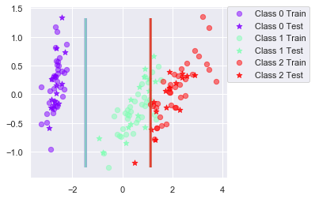

```python
%matplotlib inline
plotBoundary(DecisionTreeClassifier(), dataset='iris',split=0.7)
```

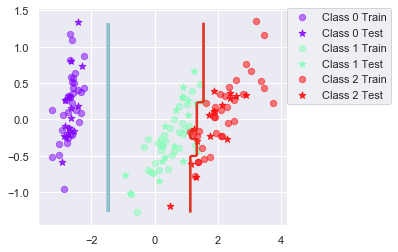

```python
%matplotlib inline
plotBoundary(BoostClassifier(DecisionTreeClassifier(), T=10), dataset='iris',split=0.7)
```

## Assignment 5 and 6

### (1) Is there any improvement in classification accuracy? Why/why not?

Naive Bayes Iris: Final mean classification accuracy 89 with standard deviation 4.16 Boosted Naive Bayes Iris: Final mean classification accuracy 94.1 with standard deviation 6.72 Decision Tree Iris: Final mean classification accuracy 92.4 with standard deviation 3.71 Boosted Decision Tree Iris: Final mean classification accuracy 94.6 with standard deviation 3.65

Naive Bayes Vowel: Final mean classification accuracy 64.7 with standard deviation 4.03 Boosted Naive Bayes Vowel: Final mean classification accuracy 80.2 with standard deviation 3.52 Decision Tree Vowel: Final mean classification accuracy 64.1 with standard deviation 4 Boosted Decision Tree Vowel: Final mean classification accuracy 86.6 with standard deviation 3

For both the naive bayes and the tree classifier there is a slight change for the iris dataset, but quite the significant one for vowels. Vowels is the more complex problem in terms of data, so it makes sense that the benefits of bundling weak classifiers together will create a better decision boundary compared to the simple version.

### (2) Plot the decision boundary of the boosted classifier on iris and compare it with that of the basic. What differences do you notice? Is the boundary of the boosted version more complex?

Bayes: The boundary between Class0 and Class1 doesn't move much, but there's a big difference in the boundary between Class1 and Class2. Besides the curve to accommodate for some of the cases on the border in the middle of the data, it also curves more to the top, seemingly following the two 'outliers' in the first quadrant. This seems to more realistically fit the data, compared to the banana shape of the single naive bayes classifier.

### (3) Can we make up for not using a more advanced model in the basic classifier (e.g. independent features) by using boosting?

Yes, this is clearly the case for both datasets. Above we can see a boosted decision tree plot that reminds me of how the SVM from lab 2 created separating hyperplanes, but in this case with a much simpler model. Same goes for the now much more complex boosted naive bayes boundary.

## Assignment 7

### If you had to pick a classifier, naive Bayes or a decision tree or the boosted versions of these, which one would you pick? Motivate from the following criteria:

#### Outliers

Non-boosted trees. Boosting can make the predictions of the "non-experts" to give too much weight to outliers, and sometimes it doesn't cancel out. Naive bayes can suffer from zero probabilites with outliers, so I would go with a tree.

#### Irrelevant inputs: part of the feature space is irrelevant

Decision trees, since information gain is used to pick the next branching feature, the irrelevant parts of the feature space truly stays irrelevant!

#### Predictive power

If I were to base it off of this lab, I'd use boosted decision trees. However, while researching the question a lot of credit was given to Naive Bayes predictive power using the concepts of prior and evidence rather than the simpler concepts of information gain and entropy. So given the literature I'd use Naive Bayes, boosted.

#### Mixed types of data: binary, categorical or continuous features, etc.

I would pick Naive bayes, since it can better accommodate for continuous features than trees. Trees can still do it, but has to potentially create a lot of cutoff points depending on the range of the continuous variable.

#### Scalability: the dimension of the data, D, is large or the number of instances, N, is large, or both.

I'd use Naive bayes since it scales O(np), where n is the number of observations, and p the number of features. Decision trees scale O(npd), where d is the depth. So the tree will always be slower unless d = 1, upon which it is equally fast.